# Report for Job [KEY:microRNA_mRNA__Linear__Yes]

WGIA

2024-08-13 20:10:32

**You can bookmark this page to access the results later, or [download the report](http://gpu.zjwm.cc:88/wgia/public/job/microRNA_mRNA__Linear__Yes/report.html) locally.**

*Results will be stored for 30 days.*

> WGIA is an open-access web application designed for genome-wide interaction analysis. Leveraging GPU parallel technologies, it significantly enhances computational efficiency. You can upload the SNP, DNA methylation, gene expression, or other biological data, and WGIA generates a comprehensive report within a short timeframe.

# 1. Datasets information

## 1.1 marker information

**There are total 100 microRNA (microRNA) and 100 Messenger RNA (mRNA) used for interaction analysis.**

- In order to provide the fullest results as possible, WGIA provided interaction for all the microRNA and mRNA uploaded, without quality control for the data.
- Note: If needed, some basic information about microRNA and mRNA can be used to perform quality control before uploaded the datasets, such as the missing rate.

# 2. Interaction analysis results

## 2.1 Regulatory effect (regression coefficient) distribution

**WGIA performed a total of 10,000 calculations between 100 microRNA and 100 mRNA for this job, encompassing linear regression among all possible microRNA-mRNA pairs. v1, v2, v3 were considered as covariates in the regression model. The results are displayed below.**

> **Regulatory relationship identification (microRNA×mRNA):** Regulatory Relationship Analysis between microRNA and mRNA investigates how microRNAs regulate mRNA expression. MicroRNAs are key post-transcriptional regulators, and understanding their interactions with mRNAs is crucial for comprehending gene regulation.  
> **Linear regression** is a statistical method used to identify the relationship between two variables. For Regulatory relationship identification (microRNA×mRNA), the linear regression model typically includes the genetic marker information of microRNA as predictor variables and the quantitative trait measurements of mRNA as the response variable. In the linear regression analysis, considering covariates helps control for confounding factors, improving the accuracy and interpretability of the association between two markers.

- These results can be downloaded here LR_distribution.txt.

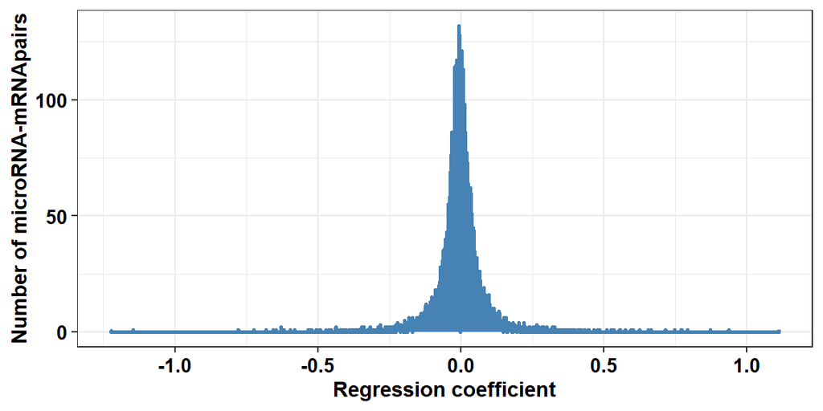

- A more rough distribution of intervals is as follows:

|  | lower_interval | upper_interval | frequency |
| --- | --- | --- | --- |
| 1 | -2 | -1 | 2 |
| 2 | -1 | -0.9 | 0 |
| 3 | -0.9 | -0.8 | 0 |
| 4 | -0.8 | -0.7 | 2 |
| 5 | -0.7 | -0.6 | 6 |
| 6 | -0.6 | -0.5 | 9 |
| 7 | -0.5 | -0.3999999999999999 | 19 |
| 8 | -0.3999999999999999 | -0.2999999999999999 | 31 |
| 9 | -0.2999999999999999 | -0.2 | 94 |
| 10 | -0.2 | -0.09999999999999998 | 470 |

[output cut: 12 more lines]

## 2.2 Regulatory effect (regression coefficient) distribution metrics

**Some basic information about the distribution is provided in the table below, including mean value, variance, standard deviation, skewness, kurtosis, median_value, lower quartile, upper quartile, interquartile range.**

- **Mean value**: The average value of the data set.
- **Variance**: A measure of how much the data points differ from the mean.
- **Standard deviation**: The square root of the variance, indicating the spread of the data.
- **Skewness**: A measure of the asymmetry of the data distribution.
- **Kurtosis**: A measure of the “tailedness” of the data distribution.
- **Median value**: The middle value that separates the higher half from the lower half of the data set.
- **Lower quartile (Q1)**: The median of the lower half of the data set (25th percentile).
- **Upper quartile (Q3)**: The median of the upper half of the data set (75th percentile).
- **Interquartile range (IQR)**: The range between the lower quartile and the upper quartile (Q3 - Q1), measuring the spread of the middle 50% of the data.
- These results can be downloaded here LR_distribution.txt. The last 9 line of the file are the metric values of the distribution.

|  | metrics | value |
| --- | --- | --- |
| 1 | mean value | -0.004524 |
| 2 | variance | 0.007048 |
| 3 | standard deviation | 0.083950 |
| 4 | skewness | 0.000017 |
| 5 | kurtosis | 0.001543 |
| 6 | lower quartile | -0.031547 |
| 7 | median_value | -0.004455 |
| 8 | upper quartile | 0.024315 |
| 9 | interquartile range | 0.055862 |

| Marker1 | Marker2 | sampleSize | variableSize | F | coefficient.0 | tvalue.0 | pvalue.0 | coefficient.1 | tvalue.1 | pvalue.1 | coefficient.2 | tvalue.2 | pvalue.2 | coefficient.3 | tvalue.3 | pvalue.3 | coefficient.4 | tvalue.4 | pvalue.4 |
| --- | --- | --- | --- | --- | --- | --- | --- | --- | --- | --- | --- | --- | --- | --- | --- | --- | --- | --- | --- |
| hsa-miR-1 | A1BG | 48.00 | 5.00 | 1.07 | 6.17 | 20.18 | 1.49e-23 | -0.09 | -1.93 | 0.06 | 0.02 | 0.95 | 0.35 | -0.31 | -0.60 | 0.55 | 0.89 | 0.36 | 0.72 |
| hsa-miR-1 | A1BG-AS1 | 48.00 | 5.00 | 0.82 | 4.85 | 14.10 | 9.84e-18 | 0.01 | 0.23 | 0.82 | 0.04 | 1.37 | 0.18 | 0.68 | 1.17 | 0.25 | -0.76 | -0.27 | 0.79 |
| hsa-miR-1 | A1CF | 48.00 | 5.00 | 2.46 | 3.01 | 12.06 | 2.16e-15 | 0.07 | 1.83 | 0.07 | -0.03 | -1.24 | 0.22 | 0.10 | 0.23 | 0.82 | -4.22 | -2.07 | 0.04 |
| hsa-miR-1 | A2M | 48.00 | 5.00 | 0.79 | 3.94 | 11.56 | 8.99e-15 | 7.53e-03 | 0.14 | 0.89 | 0.01 | 0.37 | 0.71 | 0.90 | 1.57 | 0.12 | -4.42 | -1.59 | 0.12 |
| hsa-miR-1 | A2M-AS1 | 48.00 | 5.00 | 1.05 | 8.66 | 9.34 | 6.59e-12 | -0.17 | -1.21 | 0.23 | 0.06 | 0.82 | 0.42 | -2.44 | -1.56 | 0.13 | 7.46 | 0.98 | 0.33 |
| hsa-miR-1 | A2ML1 | 48.00 | 5.00 | 0.67 | 2.72 | 10.95 | 5.09e-14 | 0.04 | 0.93 | 0.36 | -0.02 | -0.91 | 0.37 | 8.44e-03 | 0.02 | 0.98 | -1.87 | -0.92 | 0.36 |

- If you need the full results, Please perform the interaction analysis with our local software WGIA.exe